# Biostat 212a Homework 4

Due Mar. 4, 2025 @ 11:59PM

Author

Wenqiang Ge UID:106371961

Published

March 2, 2025

```r
# Load necessary libraries
library(ggplot2)
library(dplyr)
library(rpart)
library(rpart.plot)
library(GGally)
library(gtsummary)
library(ranger)
library(tidyverse)
library(tidymodels)
library(ISLR2)
library(MASS)
library(randomForest)
library(gbm)
library(caret)
library(Metrics)
library(doParallel)
library(future)
library(vip)
library(xgboost)
```

## 1 ISL Exercise 8.4.3 (10pts)

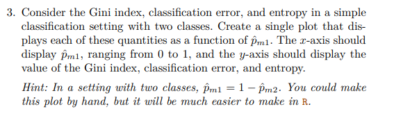

Solution:

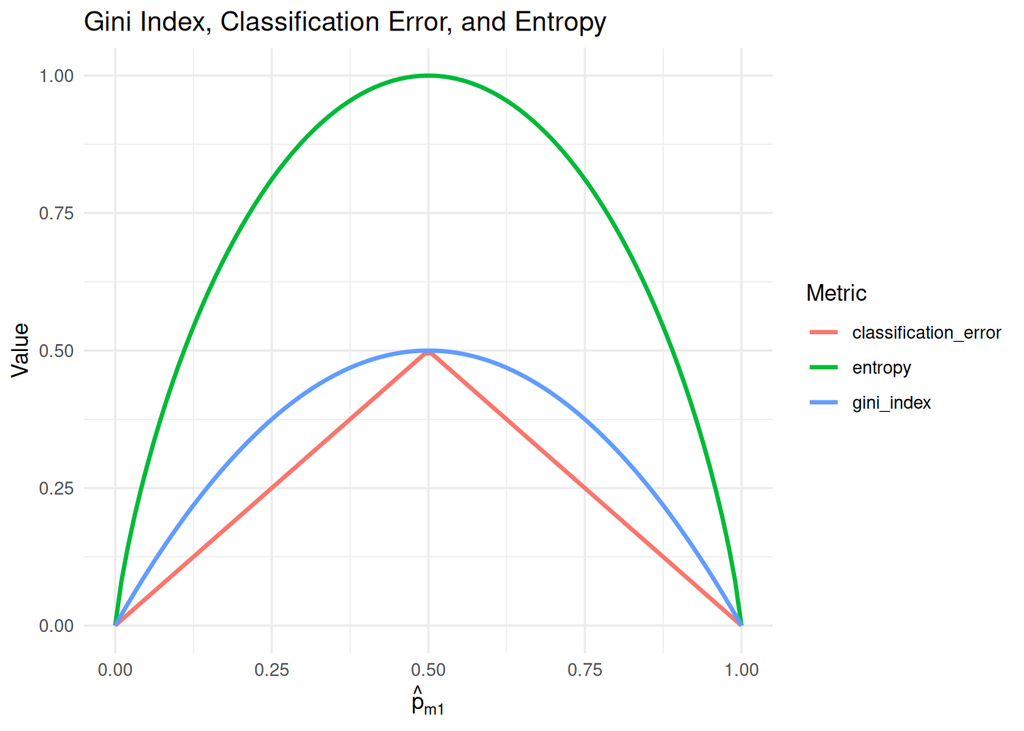

```r
# Define probability range for class 1
p_m1 <- seq(0, 1, length.out = 100)  # Probability values from 0 to 1
p_m2 <- 1 - p_m1  # Probability of the second class

# Compute the three metrics
gini_index <- 1 - (p_m1^2 + p_m2^2)  # Gini index formula
classification_error <- pmin(p_m1, p_m2)  # Classification error (minimum probability)
entropy <- - (p_m1 * log2(p_m1) + p_m2 * log2(p_m2))  # Entropy formula
entropy[is.na(entropy)] <- 0  # Handle log(0) cases (replace NaN with 0)

# Create a dataframe with all values
df <- data.frame(p_m1, gini_index, classification_error, entropy) %>%
  tidyr::pivot_longer(cols = -p_m1, names_to = "Metric", values_to = "Value")

# Plot the metrics as a function of p_m1
ggplot(df, aes(x = p_m1, y = Value, color = Metric)) +
  geom_line(size = 1) +  # Add lines for each metric
  labs(title = "Gini Index, Classification Error, and Entropy",
       x = expression(hat(p)[m1]), y = "Value") +
  theme_minimal()  # Use a clean theme for better visualization
```

## 2 ISL Exercise 8.4.4 (10pts)

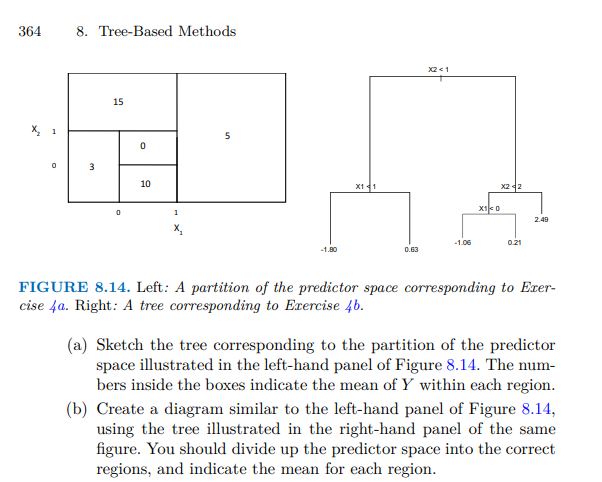

Solution:

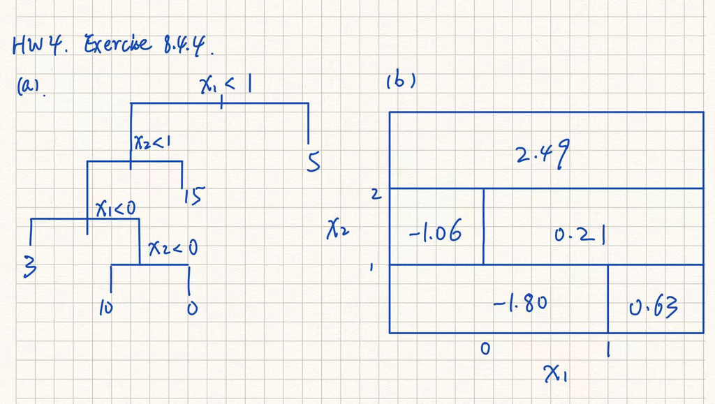

## 3 ISL Exercise 8.4.5 (10pts)

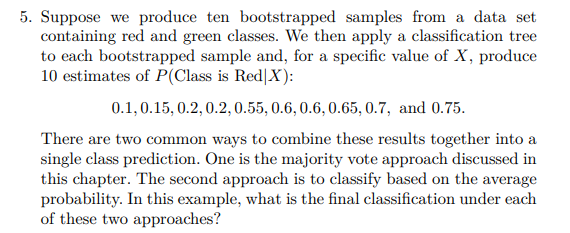

Solution:

Given probabilities of $P(Class\ is\ Red∣X)$: 0.1,0.15,0.2,0.2,0.55,0.6,0.6,0.65,0.7,0.75

Majority Vote Approach: Each estimate can be converted into a binary decision by using a threshold of $0.5:$ If $P(Red∣X)≥0.5,$ classify as Red. If $P(Red∣X)<0.5,$classify as Green.

Now, applying this threshold: Green $P<0.5\ :\ 4$ times.

Red $P>= 0.5 :\ 6$ times.

Since Red occurs more often, the majority vote approach classifies Red.

Average Probability Approach:

$\frac{0.1 + 0.15 + 0.2 + 0.2 + 0.55 + 0.6 + 0.6 + 0.65 + 0.7 + 0.75}{10}\ =\ 0.45$  
Since $0.45 < 0.5,$ the final classification under the average probability approach is Green.

Majority vote: Red

Average probability: Green

## 4 ISL Lab 8.3. `Boston` data set (30pts)

Follow the machine learning workflow to train regression tree, random forest, and boosting methods for predicting `medv`. Evaluate out-of-sample performance on a test set.

Solution:

```r
Boston %>% tbl_summary()
```

| **Characteristic** | **N = 506**<sup>1</sup> |
| --- | --- |
| crim | 0.3 (0.1, 3.7) |
| zn | 0 (0, 13) |
| indus | 9.7 (5.2, 18.1) |
| chas | 35 (6.9%) |
| nox | 0.54 (0.45, 0.62) |
| rm | 6.21 (5.89, 6.63) |
| age | 78 (45, 94) |
| dis | 3.21 (2.10, 5.21) |
| rad |  |
| 1 | 20 (4.0%) |
| 2 | 24 (4.7%) |
| 3 | 38 (7.5%) |
| 4 | 110 (22%) |
| 5 | 115 (23%) |
| 6 | 26 (5.1%) |
| 7 | 17 (3.4%) |
| 8 | 24 (4.7%) |
| 24 | 132 (26%) |
| tax | 330 (279, 666) |
| ptratio | 19.05 (17.40, 20.20) |
| black | 391 (375, 396) |
| lstat | 11 (7, 17) |
| medv | 21 (17, 25) |

<sup>1</sup> Median (Q1, Q3); n (%)

```r
Boston <- Boston %>% filter(!is.na(medv))
```

### 4.1 Regression tree

##### 4.1.0.1 Initial split into test and non-test sets

```r
# For reproducibility
set.seed(203)

data_split <- initial_split(
  Boston,
  prop = 0.5
  )
data_split
```

```
<Training/Testing/Total>
<253/253/506>
```

```r
Boston_other <- training(data_split)
dim(Boston_other)
```

```
[1] 253  14
```

```r
Boston_test <- testing(data_split)
dim(Boston_test)
```

```
[1] 253  14
```

##### 4.1.0.2 Recipe (R)

```r
# Define an untrained recipe
tree_recipe <- recipe(medv ~ ., data = Boston) %>%
  step_naomit(all_predictors()) %>%
  step_dummy(all_nominal_predictors()) %>%
  step_zv(all_numeric_predictors()) %>%
  step_normalize(all_numeric_predictors())

tree_recipe
```

##### 4.1.0.3 Model

```r
#Model
regtree_mod <- decision_tree(
  cost_complexity = tune(),
  tree_depth = tune(),
  min_n = 5,
  mode = "regression",
  engine = "rpart"
  )
```

##### 4.1.0.4 Workflow

```r
#Workflow
tree_wf <- workflow() %>%
  add_recipe(tree_recipe) %>%
  add_model(regtree_mod)
tree_wf
```

```
══ Workflow ════════════════════════════════════════════════════════════════════
Preprocessor: Recipe
Model: decision_tree()

── Preprocessor ────────────────────────────────────────────────────────────────
4 Recipe Steps

• step_naomit()
• step_dummy()
• step_zv()
• step_normalize()

── Model ───────────────────────────────────────────────────────────────────────
Decision Tree Model Specification (regression)

Main Arguments:
  cost_complexity = tune()
  tree_depth = tune()
  min_n = 5

Computational engine: rpart
```

##### 4.1.0.5 Tuning grid

```r
#Tuning
tree_grid <- grid_regular(cost_complexity(),
                          tree_depth(),
                          levels = c(100, 5))
```

##### 4.1.0.6 Cross-validation

```r
#Cross-validation
set.seed(203)

folds <- vfold_cv(Boston_other, v = 5)
#Fit cross-validation
tree_fit <- tree_wf %>%
  tune_grid(
    resamples = folds,
    grid = tree_grid,
    metrics = metric_set(yardstick::rmse, yardstick::rsq)
    )
tree_fit
```

```
# Tuning results
# 5-fold cross-validation
# A tibble: 5 × 4
  splits           id    .metrics             .notes
  <list>           <chr> <list>               <list>
1 <split [202/51]> Fold1 <tibble [1,000 × 6]> <tibble [0 × 3]>
2 <split [202/51]> Fold2 <tibble [1,000 × 6]> <tibble [0 × 3]>
3 <split [202/51]> Fold3 <tibble [1,000 × 6]> <tibble [0 × 3]>
4 <split [203/50]> Fold4 <tibble [1,000 × 6]> <tibble [0 × 3]>
5 <split [203/50]> Fold5 <tibble [1,000 × 6]> <tibble [0 × 3]>
```

```
# A tibble: 1,000 × 8
   cost_complexity tree_depth .metric .estimator  mean     n std_err
             <dbl>      <int> <chr>   <chr>      <dbl> <int>   <dbl>
 1        1   e-10          1 rmse    standard   7.94      5  0.442
 2        1   e-10          1 rsq     standard   0.347     5  0.0740
 3        1.23e-10          1 rmse    standard   7.94      5  0.442
 4        1.23e-10          1 rsq     standard   0.347     5  0.0740
 5        1.52e-10          1 rmse    standard   7.94      5  0.442
 6        1.52e-10          1 rsq     standard   0.347     5  0.0740
 7        1.87e-10          1 rmse    standard   7.94      5  0.442
 8        1.87e-10          1 rsq     standard   0.347     5  0.0740
 9        2.31e-10          1 rmse    standard   7.94      5  0.442
10        2.31e-10          1 rsq     standard   0.347     5  0.0740
   .config
   <chr>
 1 Preprocessor1_Model001
 2 Preprocessor1_Model001
 3 Preprocessor1_Model002
 4 Preprocessor1_Model002
 5 Preprocessor1_Model003
 6 Preprocessor1_Model003
 7 Preprocessor1_Model004
 8 Preprocessor1_Model004
 9 Preprocessor1_Model005
10 Preprocessor1_Model005
# ℹ 990 more rows
```

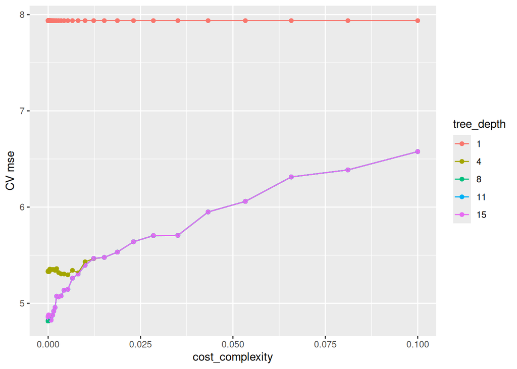

```r
#Visualize CV results
tree_fit %>%
  collect_metrics() %>%
  print(width = Inf) %>%
  filter(.metric == "rmse") %>%
  mutate(tree_depth = as.factor(tree_depth)) %>%
  ggplot(mapping = aes(x = cost_complexity, y = mean, color = tree_depth)) +
  geom_point() +
  geom_line() +
  labs(x = "cost_complexity", y = "CV mse")
```

##### 4.1.0.7 Finalize the model

```r
tree_fit %>%
  show_best(metric = "rmse", n = 5)
```

```
# A tibble: 5 × 8
  cost_complexity tree_depth .metric .estimator  mean     n std_err .config
            <dbl>      <int> <chr>   <chr>      <dbl> <int>   <dbl> <chr>
1        1   e-10          8 rmse    standard    4.82     5   0.726 Preprocesso…
2        1.23e-10          8 rmse    standard    4.82     5   0.726 Preprocesso…
3        1.52e-10          8 rmse    standard    4.82     5   0.726 Preprocesso…
4        1.87e-10          8 rmse    standard    4.82     5   0.726 Preprocesso…
5        2.31e-10          8 rmse    standard    4.82     5   0.726 Preprocesso…
```

```r
best_tree <- tree_fit %>%
  select_best(metric = "rmse")
best_tree
```

```
# A tibble: 1 × 3
  cost_complexity tree_depth .config
            <dbl>      <int> <chr>
1    0.0000000001          8 Preprocessor1_Model201
```

```r
# Final workflow
final_wf <- tree_wf %>%
  finalize_workflow(best_tree)
final_wf
```

```
══ Workflow ════════════════════════════════════════════════════════════════════
Preprocessor: Recipe
Model: decision_tree()

── Preprocessor ────────────────────────────────────────────────────────────────
4 Recipe Steps

• step_naomit()
• step_dummy()
• step_zv()
• step_normalize()

── Model ───────────────────────────────────────────────────────────────────────
Decision Tree Model Specification (regression)

Main Arguments:
  cost_complexity = 1e-10
  tree_depth = 8
  min_n = 5

Computational engine: rpart
```

```r
# Fit the whole training set, then predict the test cases
final_fit <-
  final_wf %>%
  last_fit(data_split)
final_fit
```

```
# Resampling results
# Manual resampling
# A tibble: 1 × 6
  splits            id               .metrics .notes   .predictions .workflow
  <list>            <chr>            <list>   <list>   <list>       <list>
1 <split [253/253]> train/test split <tibble> <tibble> <tibble>     <workflow>
```

```r
# Test metrics
final_fit %>%
  collect_metrics()
```

```
# A tibble: 2 × 4
  .metric .estimator .estimate .config
  <chr>   <chr>          <dbl> <chr>
1 rmse    standard       4.97  Preprocessor1_Model1
2 rsq     standard       0.716 Preprocessor1_Model1
```

##### 4.1.0.8 Visualize the final model

```r
final_tree <- extract_workflow(final_fit)
final_tree
```

```
══ Workflow [trained] ══════════════════════════════════════════════════════════
Preprocessor: Recipe
Model: decision_tree()

── Preprocessor ────────────────────────────────────────────────────────────────
4 Recipe Steps

• step_naomit()
• step_dummy()
• step_zv()
• step_normalize()

── Model ───────────────────────────────────────────────────────────────────────
n= 253

node), split, n, deviance, yval
      * denotes terminal node

  1) root 253 2.337441e+04 22.451380
    2) rm< 0.697884 208 8.878604e+03 19.383650
      4) lstat>=0.2888357 83 1.457504e+03 14.308430
        8) crim>=0.16539 42 4.284764e+02 11.764290
         16) lstat>=1.065022 22 2.211150e+02 10.150000
           32) nox>=0.7459829 19 8.364000e+01  9.200000
             64) lstat>=1.639685 9 1.810889e+01  7.611111
              128) dis< -1.083781 2 8.450000e-01  5.650000 *
              129) dis>=-1.083781 7 7.374286e+00  8.171429
                258) crim>=1.486993 3 8.000000e-02  7.200000 *
                259) crim< 1.486993 4 2.340000e+00  8.900000 *
             65) lstat< 1.639685 10 2.236100e+01 10.630000
              130) nox< 1.203607 5 9.652000e+00  9.760000
                260) age>=1.120657 2 4.500000e+00  8.700000 *
                261) age< 1.120657 3 1.406667e+00 10.466670 *
              131) nox>=1.203607 5 5.140000e+00 11.500000
                262) crim>=0.9254287 2 4.500000e-02 10.650000 *
                263) crim< 0.9254287 3 2.686667e+00 12.066670 *
           33) nox< 0.7459829 3 1.172667e+01 16.166670 *
         17) lstat< 1.065022 20 8.696800e+01 13.540000
           34) age< 1.117024 17 6.234471e+01 13.082350
             68) rm< -0.683543 2 5.120000e+00 10.100000 *
```

[output cut: 11 more lines]

```
              145) age< 1.048007 5 1.442800e+01 14.220000
                290) crim>=-0.3052468 3 1.400000e-01 13.000000 *
                291) crim< -0.3052468 2 3.125000e+00 16.050000 *
             73) rad>=-0.5746709 9 3.828000e+01 16.000000
              146) black< -1.317335 4 7.370000e+00 14.250000 *
              147) black>=-1.317335 5 8.860000e+00 17.400000
                294) nox>=0.7968301 3 2.906667e+00 16.533330 *
                295) nox< 0.7968301 2 3.200000e-01 18.700000 *
           37) black>=0.2746026 21 1.063124e+02 17.480950
             74) age>=0.8609327 11 3.508727e+01 15.954550
              148) lstat>=1.036538 4 1.347500e+00 13.925000 *
              149) lstat< 1.036538 7 7.848571e+00 17.114290

...
and 74 more lines.
```

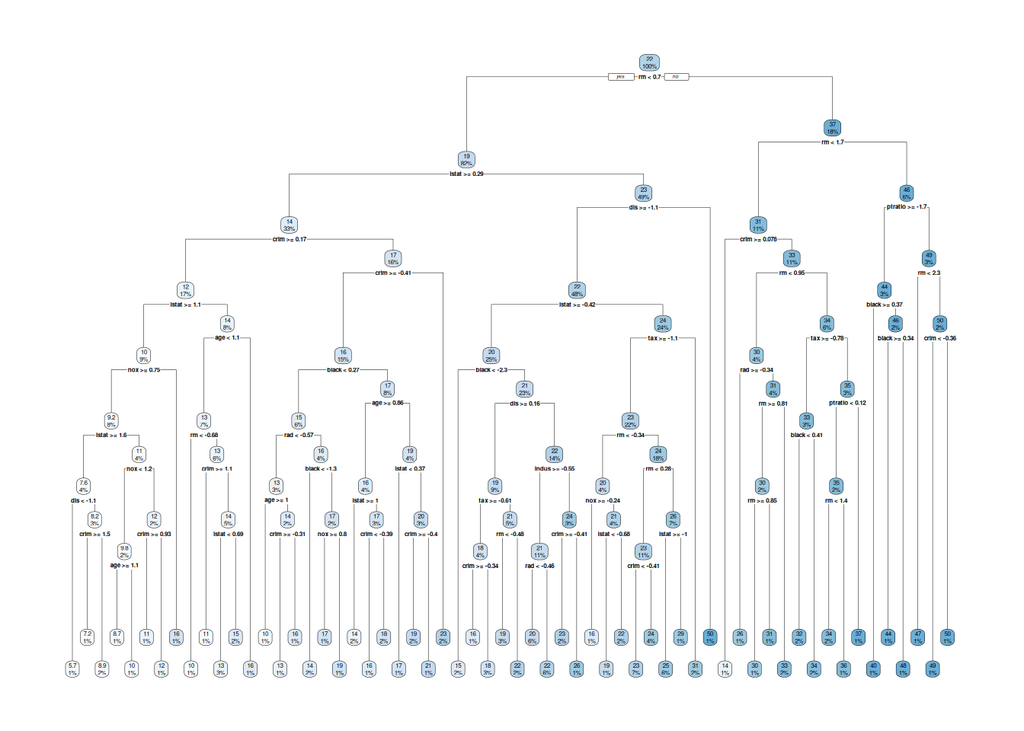

```r
final_tree %>%
  extract_fit_engine() %>%
  rpart.plot(roundint = FALSE)
```

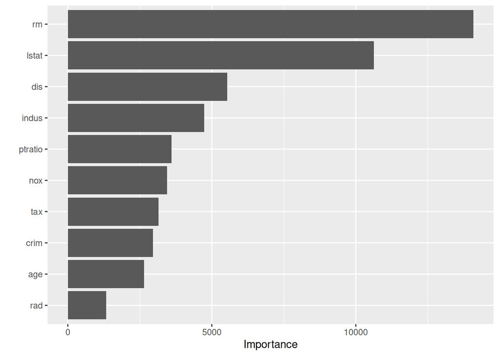

```r
final_tree %>%
  extract_fit_parsnip() %>%
  vip()
```

### 4.2 Random forest

```r
#Recipe
rf_recipe <-
  recipe(
    medv ~ .,
    data = Boston_other
  ) %>%
  step_naomit(medv) %>%
  step_zv(all_numeric_predictors())
rf_recipe

#Model
rf_mod <-
  rand_forest(
    mode = "regression",
    mtry = tune(),
    trees = tune()
  ) %>%
  set_engine("ranger")
rf_mod
```

```
Random Forest Model Specification (regression)

Main Arguments:
  mtry = tune()
  trees = tune()

Computational engine: ranger
```

```r
#Workflow
rf_wf <- workflow() %>%
  add_recipe(rf_recipe) %>%
  add_model(rf_mod)
rf_wf
```

```
══ Workflow ════════════════════════════════════════════════════════════════════
Preprocessor: Recipe
Model: rand_forest()

── Preprocessor ────────────────────────────────────────────────────────────────
2 Recipe Steps

• step_naomit()
• step_zv()

── Model ───────────────────────────────────────────────────────────────────────
Random Forest Model Specification (regression)

Main Arguments:
  mtry = tune()
  trees = tune()

Computational engine: ranger
```

```r
#Tuning
param_grid <- grid_regular(
  trees(range = c(100L, 300L)),
  mtry(range = c(1L, 5L)),
  levels = c(3, 5)
  )
param_grid
```

```
# A tibble: 15 × 2
   trees  mtry
   <int> <int>
 1   100     1
 2   200     1
 3   300     1
 4   100     2
 5   200     2
 6   300     2
 7   100     3
 8   200     3
 9   300     3
10   100     4
11   200     4
12   300     4
13   100     5
14   200     5
15   300     5
```

```r
#Cross-validation
set.seed(203)

folds <- vfold_cv(Boston_other, v = 5)
folds
```

```
#  5-fold cross-validation
# A tibble: 5 × 2
  splits           id
  <list>           <chr>
1 <split [202/51]> Fold1
2 <split [202/51]> Fold2
3 <split [202/51]> Fold3
4 <split [203/50]> Fold4
5 <split [203/50]> Fold5
```

```r
rf_fit <- rf_wf %>%
  tune_grid(
    resamples = folds,
    grid = param_grid,
    metrics = metric_set(yardstick::rmse, yardstick::rsq)
    )
rf_fit
```

```
# Tuning results
# 5-fold cross-validation
# A tibble: 5 × 4
  splits           id    .metrics          .notes
  <list>           <chr> <list>            <list>
1 <split [202/51]> Fold1 <tibble [30 × 6]> <tibble [0 × 3]>
2 <split [202/51]> Fold2 <tibble [30 × 6]> <tibble [0 × 3]>
3 <split [202/51]> Fold3 <tibble [30 × 6]> <tibble [0 × 3]>
4 <split [203/50]> Fold4 <tibble [30 × 6]> <tibble [0 × 3]>
5 <split [203/50]> Fold5 <tibble [30 × 6]> <tibble [0 × 3]>
```

```
# A tibble: 30 × 8
    mtry trees .metric .estimator  mean     n std_err .config
   <int> <int> <chr>   <chr>      <dbl> <int>   <dbl> <chr>
 1     1   100 rmse    standard   5.07      5  0.417  Preprocessor1_Model01
 2     1   100 rsq     standard   0.749     5  0.0838 Preprocessor1_Model01
 3     1   200 rmse    standard   5.17      5  0.417  Preprocessor1_Model02
 4     1   200 rsq     standard   0.741     5  0.0863 Preprocessor1_Model02
 5     1   300 rmse    standard   5.13      5  0.465  Preprocessor1_Model03
 6     1   300 rsq     standard   0.741     5  0.0904 Preprocessor1_Model03
 7     2   100 rmse    standard   4.45      5  0.637  Preprocessor1_Model04
 8     2   100 rsq     standard   0.778     5  0.0988 Preprocessor1_Model04
 9     2   200 rmse    standard   4.27      5  0.564  Preprocessor1_Model05
10     2   200 rsq     standard   0.796     5  0.0859 Preprocessor1_Model05
# ℹ 20 more rows
```

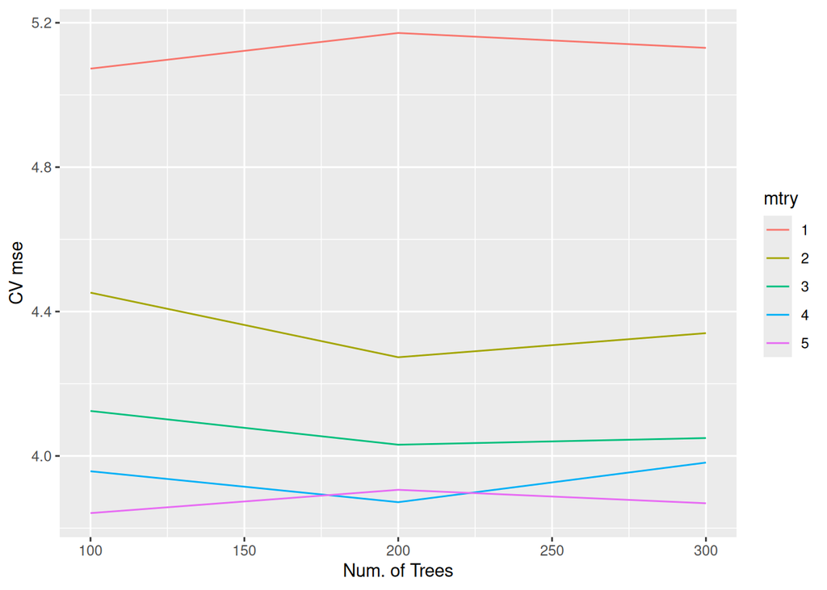

```r
rf_fit %>%
  collect_metrics() %>%
  print(width = Inf) %>%
  filter(.metric == "rmse") %>%
  mutate(mtry = as.factor(mtry)) %>%
  ggplot(mapping = aes(x = trees, y = mean, color = mtry)) +
  # geom_point() +
  geom_line() +
  labs(x = "Num. of Trees", y = "CV mse")
```

```r
rf_fit %>%
  show_best(metric = "rmse")
```

```
# A tibble: 5 × 8
   mtry trees .metric .estimator  mean     n std_err .config
  <int> <int> <chr>   <chr>      <dbl> <int>   <dbl> <chr>
1     5   100 rmse    standard    3.84     5   0.612 Preprocessor1_Model13
2     5   300 rmse    standard    3.87     5   0.598 Preprocessor1_Model15
3     4   200 rmse    standard    3.87     5   0.590 Preprocessor1_Model11
4     5   200 rmse    standard    3.91     5   0.593 Preprocessor1_Model14
5     4   100 rmse    standard    3.96     5   0.602 Preprocessor1_Model10
```

```r
best_rf <- rf_fit %>%
  select_best(metric = "rmse")
best_rf
```

```
# A tibble: 1 × 3
   mtry trees .config
  <int> <int> <chr>
1     5   100 Preprocessor1_Model13
```

```r
# Final workflow
final_wf <- rf_wf %>%
  finalize_workflow(best_rf)
final_wf
```

```
══ Workflow ════════════════════════════════════════════════════════════════════
Preprocessor: Recipe
Model: rand_forest()

── Preprocessor ────────────────────────────────────────────────────────────────
2 Recipe Steps

• step_naomit()
• step_zv()

── Model ───────────────────────────────────────────────────────────────────────
Random Forest Model Specification (regression)

Main Arguments:
  mtry = 5
  trees = 100

Computational engine: ranger
```

```r
# Fit the whole training set, then predict the test cases
final_fit <-
  final_wf %>%
  last_fit(data_split)
final_fit
```

```
# Resampling results
# Manual resampling
# A tibble: 1 × 6
  splits            id               .metrics .notes   .predictions .workflow
  <list>            <chr>            <list>   <list>   <list>       <list>
1 <split [253/253]> train/test split <tibble> <tibble> <tibble>     <workflow>
```

```r
# Test metrics
final_fit %>%
  collect_metrics()
```

```
# A tibble: 2 × 4
  .metric .estimator .estimate .config
  <chr>   <chr>          <dbl> <chr>
1 rmse    standard       3.18  Preprocessor1_Model1
2 rsq     standard       0.869 Preprocessor1_Model1
```

### 4.3 Boosting methods

##### 4.3.0.1 Recipe (R)

```r
#Recipe
gb_recipe <-
  recipe(
    medv ~ .,
    data = Boston_other
  ) %>%
  step_naomit(medv) %>%
  step_zv(all_numeric_predictors())
gb_recipe
```

##### 4.3.0.2 Model

```r
#Model
gb_mod <-
  boost_tree(
    mode = "regression",
    trees = 1000,
    tree_depth = tune(),
    learn_rate = tune()
  ) %>%
  set_engine("xgboost")
gb_mod
```

```
Boosted Tree Model Specification (regression)

Main Arguments:
  trees = 1000
  tree_depth = tune()
  learn_rate = tune()

Computational engine: xgboost
```

##### 4.3.0.3 Workflow & Tuning

```r
#Workflow
gb_wf <- workflow() %>%
  add_recipe(gb_recipe) %>%
  add_model(gb_mod)
gb_wf
```

```
══ Workflow ════════════════════════════════════════════════════════════════════
Preprocessor: Recipe
Model: boost_tree()

── Preprocessor ────────────────────────────────────────────────────────────────
2 Recipe Steps

• step_naomit()
• step_zv()

── Model ───────────────────────────────────────────────────────────────────────
Boosted Tree Model Specification (regression)

Main Arguments:
  trees = 1000
  tree_depth = tune()
  learn_rate = tune()

Computational engine: xgboost
```

```r
#Tuning
param_grid <- grid_regular(
  tree_depth(range = c(1L, 4L)),
  learn_rate(range = c(-3, -0.5), trans = log10_trans()),
  levels = c(4, 10)
  )
param_grid
```

```
# A tibble: 40 × 2
   tree_depth learn_rate
        <int>      <dbl>
 1          1    0.001
 2          2    0.001
 3          3    0.001
 4          4    0.001
 5          1    0.00190
 6          2    0.00190
 7          3    0.00190
 8          4    0.00190
 9          1    0.00359
10          2    0.00359
# ℹ 30 more rows
```

##### 4.3.0.4 Cross-validation

```r
#Cross-validation
set.seed(203)

folds <- vfold_cv(Boston_other, v = 5)
folds
```

```
#  5-fold cross-validation
# A tibble: 5 × 2
  splits           id
  <list>           <chr>
1 <split [202/51]> Fold1
2 <split [202/51]> Fold2
3 <split [202/51]> Fold3
4 <split [203/50]> Fold4
5 <split [203/50]> Fold5
```

```r
gb_fit <- gb_wf %>%
  tune_grid(
    resamples = folds,
    grid = param_grid,
    metrics = metric_set(yardstick::rmse, yardstick::rsq)
    )
gb_fit
```

```
# Tuning results
# 5-fold cross-validation
# A tibble: 5 × 4
  splits           id    .metrics          .notes
  <list>           <chr> <list>            <list>
1 <split [202/51]> Fold1 <tibble [80 × 6]> <tibble [0 × 3]>
2 <split [202/51]> Fold2 <tibble [80 × 6]> <tibble [0 × 3]>
3 <split [202/51]> Fold3 <tibble [80 × 6]> <tibble [0 × 3]>
4 <split [203/50]> Fold4 <tibble [80 × 6]> <tibble [0 × 3]>
5 <split [203/50]> Fold5 <tibble [80 × 6]> <tibble [0 × 3]>
```

```
# A tibble: 80 × 8
   tree_depth learn_rate .metric .estimator   mean     n std_err
        <int>      <dbl> <chr>   <chr>       <dbl> <int>   <dbl>
 1          1    0.001   rmse    standard   10.7       5  0.392
 2          1    0.001   rsq     standard    0.714     5  0.0598
 3          2    0.001   rmse    standard   10.2       5  0.445
 4          2    0.001   rsq     standard    0.750     5  0.0861
 5          3    0.001   rmse    standard   10.2       5  0.434
 6          3    0.001   rsq     standard    0.765     5  0.0837
 7          4    0.001   rmse    standard   10.1       5  0.418
 8          4    0.001   rsq     standard    0.769     5  0.0820
 9          1    0.00190 rmse    standard    6.64      5  0.400
10          1    0.00190 rsq     standard    0.752     5  0.0732
   .config
   <chr>
 1 Preprocessor1_Model01
 2 Preprocessor1_Model01
 3 Preprocessor1_Model02
 4 Preprocessor1_Model02
 5 Preprocessor1_Model03
 6 Preprocessor1_Model03
 7 Preprocessor1_Model04
 8 Preprocessor1_Model04
 9 Preprocessor1_Model05
10 Preprocessor1_Model05
# ℹ 70 more rows
```

[figure not shown]

```r
gb_fit %>%
  collect_metrics() %>%
  print(width = Inf) %>%
  filter(.metric == "rmse") %>%
  ggplot(mapping = aes(x = learn_rate, y = mean, color = factor(tree_depth))) +
  geom_point() +
  geom_line() +
  labs(x = "Learning Rate", y = "CV AUC") +
  scale_x_log10()
```

```r
gb_fit %>%
  show_best(metric = "rmse")
```

```
# A tibble: 5 × 8
  tree_depth learn_rate .metric .estimator  mean     n std_err .config
       <int>      <dbl> <chr>   <chr>      <dbl> <int>   <dbl> <chr>
1          3     0.0880 rmse    standard    3.77     5   0.382 Preprocessor1_Mo…
2          3     0.0245 rmse    standard    3.80     5   0.422 Preprocessor1_Mo…
3          3     0.0129 rmse    standard    3.81     5   0.458 Preprocessor1_Mo…
4          2     0.167  rmse    standard    3.81     5   0.351 Preprocessor1_Mo…
5          4     0.167  rmse    standard    3.81     5   0.393 Preprocessor1_Mo…
```

```r
best_gb <- gb_fit %>%
  select_best(metric = "rmse")
best_gb
```

```
# A tibble: 1 × 3
  tree_depth learn_rate .config
       <int>      <dbl> <chr>
1          3     0.0880 Preprocessor1_Model31
```

##### 4.3.0.5 Finalize the model

```r
#Final model
final_wf <- gb_wf %>%
  finalize_workflow(best_gb)
final_wf
```

```
══ Workflow ════════════════════════════════════════════════════════════════════
Preprocessor: Recipe
Model: boost_tree()

── Preprocessor ────────────────────────────────────────────────────────────────
2 Recipe Steps

• step_naomit()
• step_zv()

── Model ───────────────────────────────────────────────────────────────────────
Boosted Tree Model Specification (regression)

Main Arguments:
  trees = 1000
  tree_depth = 3
  learn_rate = 0.0879922543569107

Computational engine: xgboost
```

```r
final_fit <-
  final_wf %>%
  last_fit(data_split)
final_fit
```

```
# Resampling results
# Manual resampling
# A tibble: 1 × 6
  splits            id               .metrics .notes   .predictions .workflow
  <list>            <chr>            <list>   <list>   <list>       <list>
1 <split [253/253]> train/test split <tibble> <tibble> <tibble>     <workflow>
```

```r
final_fit %>%
  collect_metrics()
```

```
# A tibble: 2 × 4
  .metric .estimator .estimate .config
  <chr>   <chr>          <dbl> <chr>
1 rmse    standard       3.63  Preprocessor1_Model1
2 rsq     standard       0.836 Preprocessor1_Model1
```

##### 4.3.0.6 Visualize the final model

```r
#Visualize the final model
final_tree <- extract_workflow(final_fit)
final_tree
```

```
══ Workflow [trained] ══════════════════════════════════════════════════════════
Preprocessor: Recipe
Model: boost_tree()

── Preprocessor ────────────────────────────────────────────────────────────────
2 Recipe Steps

• step_naomit()
• step_zv()

── Model ───────────────────────────────────────────────────────────────────────
##### xgb.Booster
raw: 1.1 Mb
call:
  xgboost::xgb.train(params = list(eta = 0.0879922543569107, max_depth = 3L,
    gamma = 0, colsample_bytree = 1, colsample_bynode = 1, min_child_weight = 1,
    subsample = 1), data = x$data, nrounds = 1000, watchlist = x$watchlist,
    verbose = 0, nthread = 1, objective = "reg:squarederror")
params (as set within xgb.train):
  eta = "0.0879922543569107", max_depth = "3", gamma = "0", colsample_bytree = "1", colsample_bynode = "1", min_child_weight = "1", subsample = "1", nthread = "1", objective = "reg:squarederror", validate_parameters = "TRUE"
xgb.attributes:
  niter
callbacks:
  cb.evaluation.log()
# of features: 13
niter: 1000
nfeatures : 13
evaluation_log:
  iter training_rmse
 <num>         <num>
     1   21.98661584
     2   20.17570809
   ---           ---
   999    0.03930784
  1000    0.03925896
```

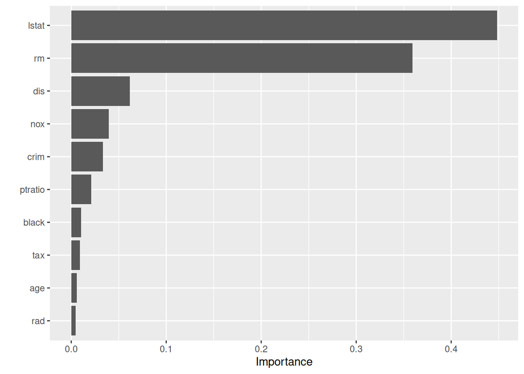

```r
final_tree %>%
  extract_fit_parsnip() %>%
  vip()
```

### 4.4 Conclusion

Considering the values of RMSE of each model, the random forest model has the lowest one ,so we can choose it as the final model.

## 5 ISL Lab 8.3 `Carseats` data set (30pts)

Follow the machine learning workflow to train classification tree, random forest, and boosting methods for classifying `Sales <= 8` versus `Sales > 8`. Evaluate out-of-sample performance on a test set.

Solution:

```r
# load the data
data("Carseats", package = "ISLR")
Carseats$AHD <- ifelse(Carseats$Sales > 8, "High", "Low")
Carseats$AHD <- as.factor(Carseats$AHD)
Carseats <- Carseats[, !names(Carseats) %in% c("Sales")]
Carseats %>% tbl_summary()
```

| **Characteristic** | **N = 400**<sup>1</sup> |
| --- | --- |
| CompPrice | 125 (115, 135) |
| Income | 69 (43, 91) |
| Advertising | 5.0 (0.0, 12.0) |
| Population | 272 (139, 399) |
| Price | 117 (100, 131) |
| ShelveLoc |  |
| Bad | 96 (24%) |
| Good | 85 (21%) |
| Medium | 219 (55%) |
| Age | 55 (40, 66) |
| Education |  |
| 10 | 48 (12%) |
| 11 | 48 (12%) |
| 12 | 49 (12%) |
| 13 | 43 (11%) |
| 14 | 40 (10%) |
| 15 | 36 (9.0%) |
| 16 | 47 (12%) |
| 17 | 49 (12%) |
| 18 | 40 (10%) |
| Urban | 282 (71%) |
| US | 258 (65%) |
| AHD |  |
| High | 164 (41%) |
| Low | 236 (59%) |

<sup>1</sup> Median (Q1, Q3); n (%)

### 5.1 Classification tree

##### 5.1.0.1 Initial split into test and non-test sets

```r
#Initial split into test and non-test sets
set.seed(212)
data_split <- initial_split(
  Carseats,
  prop = 0.5,
  strata = AHD
  )
data_split
```

```
<Training/Testing/Total>
<200/200/400>
```

```r
Carseats_other <- training(data_split)
dim(Carseats_other)
```

```
[1] 200  11
```

```r
Carseats_test <- testing(data_split)
dim(Carseats_test)
```

```
[1] 200  11
```

##### 5.1.0.2 Recipe

```r
#Recipe
tree_recipe <-
  recipe(
    AHD ~ .,
    data = Carseats_other
  ) %>%
  step_naomit(all_predictors()) %>%
  # create traditional dummy variables (not necessary for random forest in R)
  step_dummy(all_nominal_predictors()) %>%
  # zero-variance filter
  step_zv(all_numeric_predictors()) %>%
  # # center and scale numeric data (not necessary for random forest)
  step_normalize(all_numeric_predictors())

tree_recipe
```

##### 5.1.0.3 Model & Workflow

```r
#Model
classtree_mod <- decision_tree(
   # Hyperparameter: Complexity parameter (cp) for pruning
  cost_complexity = tune(),
  # Hyperparameter: Maximum depth of the tree
  tree_depth = tune(),
  min_n = 5,
  mode = "classification",
  engine = "rpart"
  )

#Workflow
tree_wf <- workflow() %>%
  add_recipe(tree_recipe) %>%
  add_model(classtree_mod)

# Print the workflow structure
tree_wf
```

```
══ Workflow ════════════════════════════════════════════════════════════════════
Preprocessor: Recipe
Model: decision_tree()

── Preprocessor ────────────────────────────────────────────────────────────────
4 Recipe Steps

• step_naomit()
• step_dummy()
• step_zv()
• step_normalize()

── Model ───────────────────────────────────────────────────────────────────────
Decision Tree Model Specification (classification)

Main Arguments:
  cost_complexity = tune()
  tree_depth = tune()
  min_n = 5

Computational engine: rpart
```

##### 5.1.0.4 Tuning grid

```r
#Tuning
tree_grid <- grid_regular(cost_complexity(),
                          tree_depth(),
                          levels = c(100,5))
```

##### 5.1.0.5 Cross-validation (CV)

```r
set.seed(212)

folds <- vfold_cv(Carseats_other, v = 5)
folds
```

```
#  5-fold cross-validation
# A tibble: 5 × 2
  splits           id
  <list>           <chr>
1 <split [160/40]> Fold1
2 <split [160/40]> Fold2
3 <split [160/40]> Fold3
4 <split [160/40]> Fold4
5 <split [160/40]> Fold5
```

```r
# Register a parallel backend using future
plan(multisession, workers = parallel::detectCores() - 1)

# Fit cross-validation.
tree_fit <- tree_wf %>%
  tune_grid(
    resamples = folds,
    grid = tree_grid,
    metrics = metric_set(yardstick::accuracy, yardstick::roc_auc),
    control = control_grid(save_pred = TRUE, parallel_over = "resamples")
  )

# Stop parallel processing after computation
plan(sequential)  # Reset to sequential processing after tuning

tree_fit
```

```
# Tuning results
# 5-fold cross-validation
# A tibble: 5 × 5
  splits           id    .metrics             .notes           .predictions
  <list>           <chr> <list>               <list>           <list>
1 <split [160/40]> Fold1 <tibble [1,000 × 6]> <tibble [0 × 3]> <tibble>
2 <split [160/40]> Fold2 <tibble [1,000 × 6]> <tibble [0 × 3]> <tibble>
3 <split [160/40]> Fold3 <tibble [1,000 × 6]> <tibble [0 × 3]> <tibble>
4 <split [160/40]> Fold4 <tibble [1,000 × 6]> <tibble [0 × 3]> <tibble>
5 <split [160/40]> Fold5 <tibble [1,000 × 6]> <tibble [0 × 3]> <tibble>
```

##### 5.1.0.6 Visualize CV results

```
# A tibble: 1,000 × 8
   cost_complexity tree_depth .metric  .estimator  mean     n std_err
             <dbl>      <int> <chr>    <chr>      <dbl> <int>   <dbl>
 1        1   e-10          1 accuracy binary     0.685     5  0.0232
 2        1   e-10          1 roc_auc  binary     0.629     5  0.0298
 3        1.23e-10          1 accuracy binary     0.685     5  0.0232
 4        1.23e-10          1 roc_auc  binary     0.629     5  0.0298
 5        1.52e-10          1 accuracy binary     0.685     5  0.0232
 6        1.52e-10          1 roc_auc  binary     0.629     5  0.0298
 7        1.87e-10          1 accuracy binary     0.685     5  0.0232
 8        1.87e-10          1 roc_auc  binary     0.629     5  0.0298
 9        2.31e-10          1 accuracy binary     0.685     5  0.0232
10        2.31e-10          1 roc_auc  binary     0.629     5  0.0298
   .config
   <chr>
 1 Preprocessor1_Model001
 2 Preprocessor1_Model001
 3 Preprocessor1_Model002
 4 Preprocessor1_Model002
 5 Preprocessor1_Model003
 6 Preprocessor1_Model003
 7 Preprocessor1_Model004
 8 Preprocessor1_Model004
 9 Preprocessor1_Model005
10 Preprocessor1_Model005
# ℹ 990 more rows
```

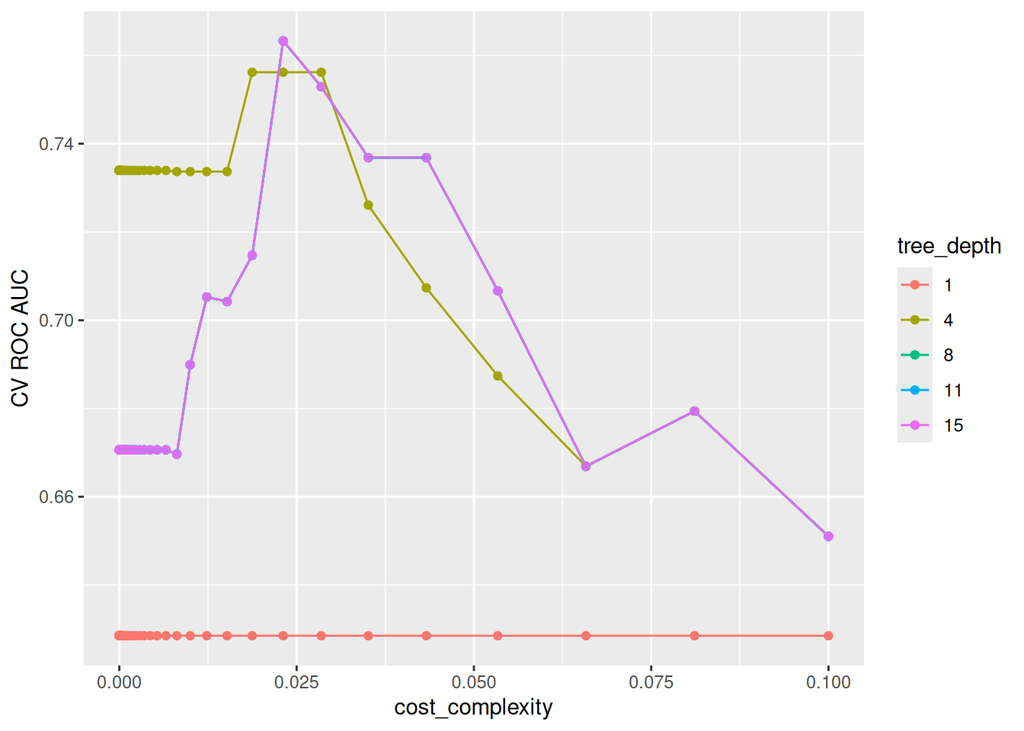

```r
tree_fit %>%
  collect_metrics() %>%
  print(width = Inf) %>%
  filter(.metric == "roc_auc") %>%
  mutate(tree_depth = as.factor(tree_depth)) %>%
  ggplot(mapping = aes(x = cost_complexity, y = mean, color = tree_depth)) +
  geom_point() +
  geom_line() +
  labs(x = "cost_complexity", y = "CV ROC AUC", color = "tree_depth")
```

##### 5.1.0.7 Finalize the model

```r
tree_fit %>%
  show_best(metric = "roc_auc", n = 5)
```

```
# A tibble: 5 × 8
  cost_complexity tree_depth .metric .estimator  mean     n std_err .config
            <dbl>      <int> <chr>   <chr>      <dbl> <int>   <dbl> <chr>
1          0.0231          8 roc_auc binary     0.763     5  0.0148 Preprocesso…
2          0.0231         11 roc_auc binary     0.763     5  0.0148 Preprocesso…
3          0.0231         15 roc_auc binary     0.763     5  0.0148 Preprocesso…
4          0.0187          4 roc_auc binary     0.756     5  0.0165 Preprocesso…
5          0.0231          4 roc_auc binary     0.756     5  0.0165 Preprocesso…
```

```r
# select the best model.
best_tree <- tree_fit %>%
  select_best(metric = "roc_auc")
best_tree
```

```
# A tibble: 1 × 3
  cost_complexity tree_depth .config
            <dbl>      <int> <chr>
1          0.0231          8 Preprocessor1_Model293
```

```r
# Final workflow
final_wf <- tree_wf %>%
  finalize_workflow(best_tree)
final_wf
```

```
══ Workflow ════════════════════════════════════════════════════════════════════
Preprocessor: Recipe
Model: decision_tree()

── Preprocessor ────────────────────────────────────────────────────────────────
4 Recipe Steps

• step_naomit()
• step_dummy()
• step_zv()
• step_normalize()

── Model ───────────────────────────────────────────────────────────────────────
Decision Tree Model Specification (classification)

Main Arguments:
  cost_complexity = 0.0231012970008316
  tree_depth = 8
  min_n = 5

Computational engine: rpart
```

##### 5.1.0.8 Visualize the final model

```r
# Fit the whole training set, then predict the test cases
final_fit <-
  final_wf %>%
  last_fit(data_split)
final_fit
```

```
# Resampling results
# Manual resampling
# A tibble: 1 × 6
  splits            id               .metrics .notes   .predictions .workflow
  <list>            <chr>            <list>   <list>   <list>       <list>
1 <split [200/200]> train/test split <tibble> <tibble> <tibble>     <workflow>
```

```r
# Test metrics
final_fit %>%
  collect_metrics()
```

```
# A tibble: 3 × 4
  .metric     .estimator .estimate .config
  <chr>       <chr>          <dbl> <chr>
1 accuracy    binary         0.755 Preprocessor1_Model1
2 roc_auc     binary         0.760 Preprocessor1_Model1
3 brier_class binary         0.208 Preprocessor1_Model1
```

```r
final_tree <- extract_workflow(final_fit)
final_tree
```

```
══ Workflow [trained] ══════════════════════════════════════════════════════════
Preprocessor: Recipe
Model: decision_tree()

── Preprocessor ────────────────────────────────────────────────────────────────
4 Recipe Steps

• step_naomit()
• step_dummy()
• step_zv()
• step_normalize()

── Model ───────────────────────────────────────────────────────────────────────
n= 200

node), split, n, loss, yval, (yprob)
      * denotes terminal node

 1) root 200 82 Low (0.41000000 0.59000000)
   2) ShelveLoc_Good>=0.6742344 44  9 High (0.79545455 0.20454545)
     4) Price< 1.204802 36  3 High (0.91666667 0.08333333) *
     5) Price>=1.204802 8  2 Low (0.25000000 0.75000000) *
   3) ShelveLoc_Good< 0.6742344 156 47 Low (0.30128205 0.69871795)
     6) Price< -0.9414209 26  8 High (0.69230769 0.30769231)
      12) Income>=0.6401903 12  1 High (0.91666667 0.08333333) *
      13) Income< 0.6401903 14  7 High (0.50000000 0.50000000)
        26) ShelveLoc_Medium>=-0.0499373 9  2 High (0.77777778 0.22222222) *
        27) ShelveLoc_Medium< -0.0499373 5  0 Low (0.00000000 1.00000000) *
     7) Price>=-0.9414209 130 29 Low (0.22307692 0.77692308)
      14) Advertising>=0.78991 26 12 High (0.53846154 0.46153846)
        28) Price< 0.8505711 20  6 High (0.70000000 0.30000000)
          56) CompPrice>=-0.787038 16  2 High (0.87500000 0.12500000) *
          57) CompPrice< -0.787038 4  0 Low (0.00000000 1.00000000) *
        29) Price>=0.8505711 6  0 Low (0.00000000 1.00000000) *
      15) Advertising< 0.78991 104 15 Low (0.14423077 0.85576923)
        30) CompPrice>=1.238547 15  6 Low (0.40000000 0.60000000)
          60) Income>=0.247091 6  1 High (0.83333333 0.16666667) *
          61) Income< 0.247091 9  1 Low (0.11111111 0.88888889) *
        31) CompPrice< 1.238547 89  9 Low (0.10112360 0.89887640) *
```

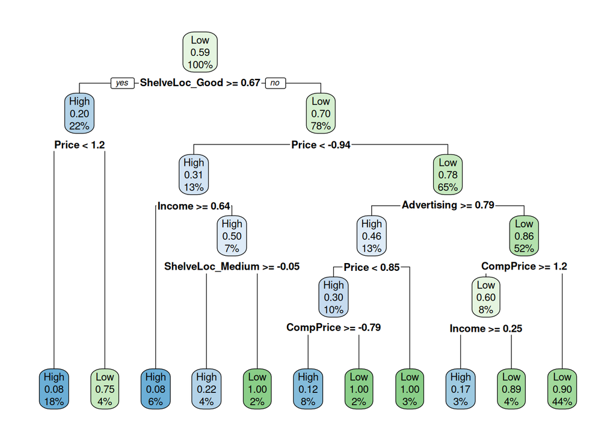

```r
final_tree %>%
  extract_fit_engine() %>%
  rpart.plot(roundint = FALSE)
```

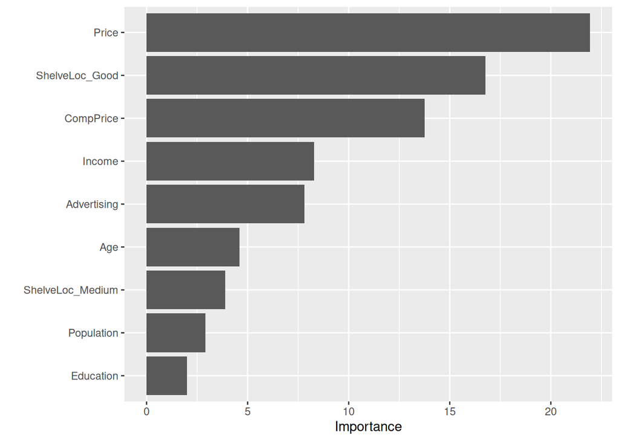

```r
final_tree %>%
  extract_fit_parsnip() %>%
  vip()
```

### 5.2 Random forest

##### 5.2.0.1 Initial split into test and non-test sets

```r
#Initial split into test and non-test sets
set.seed(212)

data_split <- initial_split(
  Carseats,
  prop = 0.75,
  strata = AHD
  )
data_split
```

```
<Training/Testing/Total>
<300/100/400>
```

```r
Carseats_other <- training(data_split)
dim(Carseats_other)
```

```
[1] 300  11
```

```r
Carseats_test <- testing(data_split)
dim(Carseats_test)
```

```
[1] 100  11
```

##### 5.2.0.2 Recipe (R)

```r
#Recipe
rf_recipe <-
  recipe(
    AHD ~ .,
    data = Carseats_other
  ) %>%
  step_zv(all_numeric_predictors())
rf_recipe
```

##### 5.2.0.3 Model

```r
#Model
rf_mod <-
  rand_forest(
    mode = "classification",
    mtry = tune(),
    trees = tune()
  ) %>%
  set_engine("ranger")
rf_mod
```

```
Random Forest Model Specification (classification)

Main Arguments:
  mtry = tune()
  trees = tune()

Computational engine: ranger
```

##### 5.2.0.4 Work & Tuning

```r
#Workflow
rf_wf <- workflow() %>%
  add_recipe(rf_recipe) %>%
  add_model(rf_mod)
rf_wf
```

```
══ Workflow ════════════════════════════════════════════════════════════════════
Preprocessor: Recipe
Model: rand_forest()

── Preprocessor ────────────────────────────────────────────────────────────────
1 Recipe Step

• step_zv()

── Model ───────────────────────────────────────────────────────────────────────
Random Forest Model Specification (classification)

Main Arguments:
  mtry = tune()
  trees = tune()

Computational engine: ranger
```

```r
#Tuning
param_grid <- grid_regular(
  trees(range = c(100L, 300L)),
  mtry(range = c(1L, 5L)),
  levels = c(3, 5)
  )
param_grid
```

```
# A tibble: 15 × 2
   trees  mtry
   <int> <int>
 1   100     1
 2   200     1
 3   300     1
 4   100     2
 5   200     2
 6   300     2
 7   100     3
 8   200     3
 9   300     3
10   100     4
11   200     4
12   300     4
13   100     5
14   200     5
15   300     5
```

##### 5.2.0.5 Cross-validation (CV)

```r
#Cross-validation
set.seed(203)

folds <- vfold_cv(Carseats_other, v = 5)
folds
```

```
#  5-fold cross-validation
# A tibble: 5 × 2
  splits           id
  <list>           <chr>
1 <split [240/60]> Fold1
2 <split [240/60]> Fold2
3 <split [240/60]> Fold3
4 <split [240/60]> Fold4
5 <split [240/60]> Fold5
```

```r
#Fit cross-validation
rf_fit <- rf_wf %>%
  tune_grid(
    resamples = folds,
    grid = param_grid,
    metrics = metric_set(yardstick::roc_auc,
                         yardstick::accuracy)
    )
rf_fit
```

```
# Tuning results
# 5-fold cross-validation
# A tibble: 5 × 4
  splits           id    .metrics          .notes
  <list>           <chr> <list>            <list>
1 <split [240/60]> Fold1 <tibble [30 × 6]> <tibble [0 × 3]>
2 <split [240/60]> Fold2 <tibble [30 × 6]> <tibble [0 × 3]>
3 <split [240/60]> Fold3 <tibble [30 × 6]> <tibble [0 × 3]>
4 <split [240/60]> Fold4 <tibble [30 × 6]> <tibble [0 × 3]>
5 <split [240/60]> Fold5 <tibble [30 × 6]> <tibble [0 × 3]>
```

```
# A tibble: 30 × 8
    mtry trees .metric  .estimator  mean     n std_err .config
   <int> <int> <chr>    <chr>      <dbl> <int>   <dbl> <chr>
 1     1   100 accuracy binary     0.753     5  0.0207 Preprocessor1_Model01
 2     1   100 roc_auc  binary     0.848     5  0.0214 Preprocessor1_Model01
 3     1   200 accuracy binary     0.747     5  0.0276 Preprocessor1_Model02
 4     1   200 roc_auc  binary     0.843     5  0.0297 Preprocessor1_Model02
 5     1   300 accuracy binary     0.76      5  0.0327 Preprocessor1_Model03
 6     1   300 roc_auc  binary     0.850     5  0.0283 Preprocessor1_Model03
 7     2   100 accuracy binary     0.767     5  0.0497 Preprocessor1_Model04
 8     2   100 roc_auc  binary     0.861     5  0.0324 Preprocessor1_Model04
 9     2   200 accuracy binary     0.777     5  0.0327 Preprocessor1_Model05
10     2   200 roc_auc  binary     0.871     5  0.0274 Preprocessor1_Model05
# ℹ 20 more rows
```

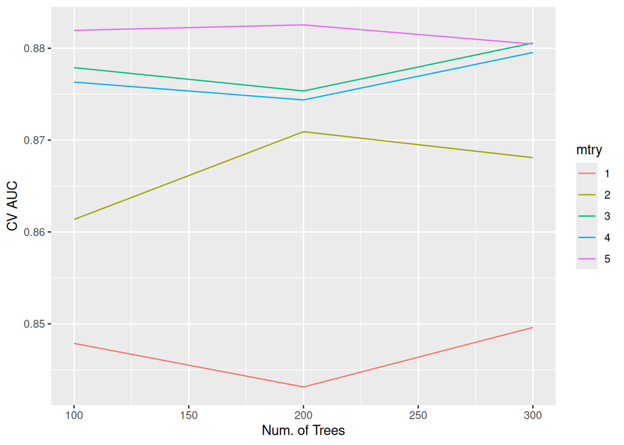

```r
#Visualize CV results
rf_fit %>%
  collect_metrics() %>%
  print(width = Inf) %>%
  filter(.metric == "roc_auc") %>%
  mutate(mtry = as.factor(mtry)) %>%
  ggplot(mapping = aes(x = trees, y = mean, color = mtry)) +
  # geom_point() +
  geom_line() +
  labs(x = "Num. of Trees", y = "CV AUC")
```

```r
#Show the top 5 models.
rf_fit %>%
  show_best(metric = "roc_auc")
```

```
# A tibble: 5 × 8
   mtry trees .metric .estimator  mean     n std_err .config
  <int> <int> <chr>   <chr>      <dbl> <int>   <dbl> <chr>
1     5   200 roc_auc binary     0.883     5  0.0264 Preprocessor1_Model14
2     5   100 roc_auc binary     0.882     5  0.0317 Preprocessor1_Model13
3     3   300 roc_auc binary     0.881     5  0.0306 Preprocessor1_Model09
4     5   300 roc_auc binary     0.880     5  0.0322 Preprocessor1_Model15
5     4   300 roc_auc binary     0.880     5  0.0284 Preprocessor1_Model12
```

```r
#Select the best model
best_rf <- rf_fit %>%
  select_best(metric = "roc_auc")
best_rf
```

```
# A tibble: 1 × 3
   mtry trees .config
  <int> <int> <chr>
1     5   200 Preprocessor1_Model14
```

##### 5.2.0.6 Finalize the model

```r
#Final model
final_wf <- rf_wf %>%
  finalize_workflow(best_rf)
final_wf
```

```
══ Workflow ════════════════════════════════════════════════════════════════════
Preprocessor: Recipe
Model: rand_forest()

── Preprocessor ────────────────────────────────────────────────────────────────
1 Recipe Step

• step_zv()

── Model ───────────────────────────────────────────────────────────────────────
Random Forest Model Specification (classification)

Main Arguments:
  mtry = 5
  trees = 200

Computational engine: ranger
```

```r
final_fit <-
  final_wf %>%
  last_fit(data_split)
final_fit
```

```
# Resampling results
# Manual resampling
# A tibble: 1 × 6
  splits            id               .metrics .notes   .predictions .workflow
  <list>            <chr>            <list>   <list>   <list>       <list>
1 <split [300/100]> train/test split <tibble> <tibble> <tibble>     <workflow>
```

```r
final_fit %>%
  collect_metrics()
```

```
# A tibble: 3 × 4
  .metric     .estimator .estimate .config
  <chr>       <chr>          <dbl> <chr>
1 accuracy    binary         0.81  Preprocessor1_Model1
2 roc_auc     binary         0.895 Preprocessor1_Model1
3 brier_class binary         0.140 Preprocessor1_Model1
```

### 5.3 Boosting methods

##### 5.3.0.1 Initial split into test and non-test sets

```r
library(xgboost)
#Initial split into test and non-test sets
set.seed(212)

data_split <- initial_split(
  Carseats,
  prop = 0.75,
  strata = AHD
  )
data_split
```

```
<Training/Testing/Total>
<300/100/400>
```

```r
Carseats_other <- training(data_split)
dim(Carseats_other)
```

```
[1] 300  11
```

```r
Carseats_test <- testing(data_split)
dim(Carseats_test)
```

```
[1] 100  11
```

##### 5.3.0.2 Recipe (R)

```r
#Recipe
gb_recipe <-
  recipe(
    AHD ~ .,
    data = Carseats_other
  ) %>%
  step_dummy(all_nominal_predictors()) %>%
  step_zv(all_numeric_predictors())
gb_recipe
```

##### 5.3.0.3 Model

```r
#Model
gb_mod <-
  boost_tree(
    mode = "classification",
    trees = 1000,
    tree_depth = tune(),
    learn_rate = tune()
  ) %>%
  set_engine("xgboost")
gb_mod
```

```
Boosted Tree Model Specification (classification)

Main Arguments:
  trees = 1000
  tree_depth = tune()
  learn_rate = tune()

Computational engine: xgboost
```

##### 5.3.0.4 Workflow & Tuning

```r
#Workflow
gb_wf <- workflow() %>%
  add_recipe(gb_recipe) %>%
  add_model(gb_mod)
gb_wf
```

```
══ Workflow ════════════════════════════════════════════════════════════════════
Preprocessor: Recipe
Model: boost_tree()

── Preprocessor ────────────────────────────────────────────────────────────────
2 Recipe Steps

• step_dummy()
• step_zv()

── Model ───────────────────────────────────────────────────────────────────────
Boosted Tree Model Specification (classification)

Main Arguments:
  trees = 1000
  tree_depth = tune()
  learn_rate = tune()

Computational engine: xgboost
```

```r
#Tuning
param_grid <- grid_regular(
  tree_depth(range = c(1L, 3L)),
  learn_rate(range = c(-5, 2), trans = log10_trans()),
  levels = c(3, 10)
  )
param_grid
```

```
# A tibble: 30 × 2
   tree_depth learn_rate
        <int>      <dbl>
 1          1  0.00001
 2          2  0.00001
 3          3  0.00001
 4          1  0.0000599
 5          2  0.0000599
 6          3  0.0000599
 7          1  0.000359
 8          2  0.000359
 9          3  0.000359
10          1  0.00215
# ℹ 20 more rows
```

##### 5.3.0.5 Cross-validation

```r
#Cross-validation
set.seed(203)

folds <- vfold_cv(Carseats_other, v = 5)
folds
```

```
#  5-fold cross-validation
# A tibble: 5 × 2
  splits           id
  <list>           <chr>
1 <split [240/60]> Fold1
2 <split [240/60]> Fold2
3 <split [240/60]> Fold3
4 <split [240/60]> Fold4
5 <split [240/60]> Fold5
```

```r
gb_fit <- gb_wf %>%
  tune_grid(
    resamples = folds,
    grid = param_grid,
    metrics = metric_set(yardstick::roc_auc,
                         yardstick::accuracy)
    )
gb_fit
```

```
# Tuning results
# 5-fold cross-validation
# A tibble: 5 × 4
  splits           id    .metrics          .notes
  <list>           <chr> <list>            <list>
1 <split [240/60]> Fold1 <tibble [60 × 6]> <tibble [0 × 3]>
2 <split [240/60]> Fold2 <tibble [60 × 6]> <tibble [0 × 3]>
3 <split [240/60]> Fold3 <tibble [60 × 6]> <tibble [0 × 3]>
4 <split [240/60]> Fold4 <tibble [60 × 6]> <tibble [0 × 3]>
5 <split [240/60]> Fold5 <tibble [60 × 6]> <tibble [0 × 3]>
```

```
# A tibble: 60 × 8
   tree_depth learn_rate .metric  .estimator  mean     n std_err
        <int>      <dbl> <chr>    <chr>      <dbl> <int>   <dbl>
 1          1  0.00001   accuracy binary     0.717     5  0.0183
 2          1  0.00001   roc_auc  binary     0.671     5  0.0181
 3          2  0.00001   accuracy binary     0.713     5  0.0309
 4          2  0.00001   roc_auc  binary     0.729     5  0.0203
 5          3  0.00001   accuracy binary     0.737     5  0.0295
 6          3  0.00001   roc_auc  binary     0.773     5  0.0258
 7          1  0.0000599 accuracy binary     0.717     5  0.0183
 8          1  0.0000599 roc_auc  binary     0.671     5  0.0181
 9          2  0.0000599 accuracy binary     0.743     5  0.0310
10          2  0.0000599 roc_auc  binary     0.736     5  0.0187
   .config
   <chr>
 1 Preprocessor1_Model01
 2 Preprocessor1_Model01
 3 Preprocessor1_Model02
 4 Preprocessor1_Model02
 5 Preprocessor1_Model03
 6 Preprocessor1_Model03
 7 Preprocessor1_Model04
 8 Preprocessor1_Model04
 9 Preprocessor1_Model05
10 Preprocessor1_Model05
# ℹ 50 more rows
```

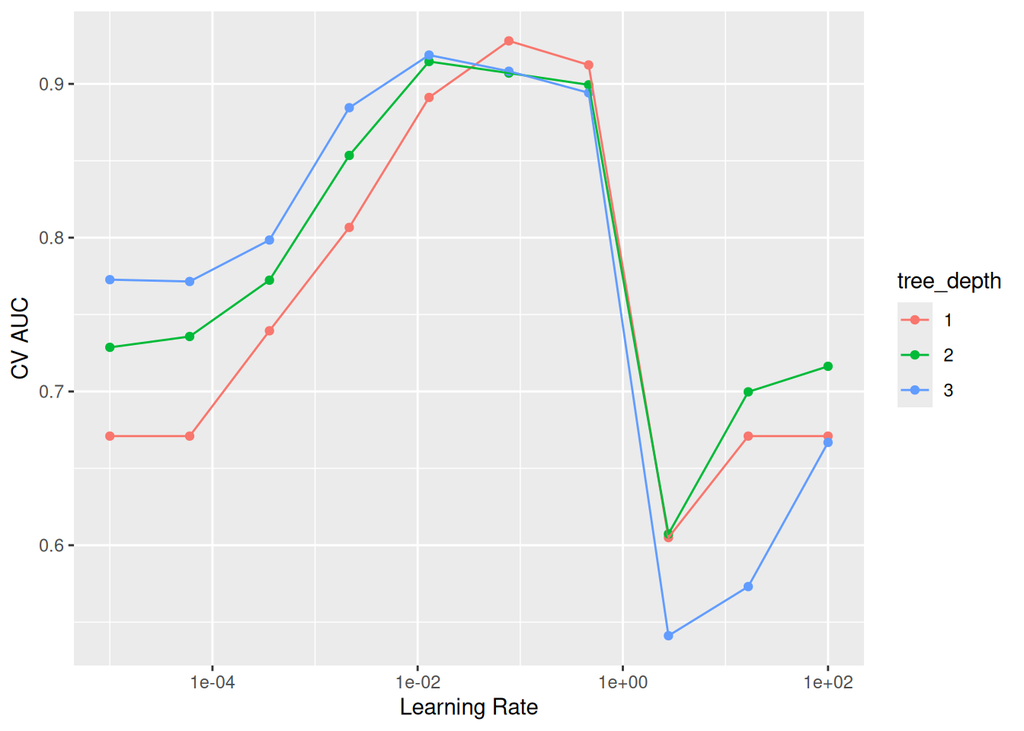

```r
gb_fit %>%
  collect_metrics() %>%
  print(width = Inf) %>%
  filter(.metric == "roc_auc") %>%
  mutate(tree_depth = as.factor(tree_depth)) %>%
  ggplot(mapping = aes(x = learn_rate, y = mean, color = tree_depth)) +
  geom_point() +
  geom_line() +
  labs(x = "Learning Rate", y = "CV AUC") +
  scale_x_log10()
```

```r
gb_fit %>%
  show_best(metric = "roc_auc")
```

```
# A tibble: 5 × 8
  tree_depth learn_rate .metric .estimator  mean     n std_err .config
       <int>      <dbl> <chr>   <chr>      <dbl> <int>   <dbl> <chr>
1          1     0.0774 roc_auc binary     0.928     5  0.0138 Preprocessor1_Mo…
2          3     0.0129 roc_auc binary     0.919     5  0.0161 Preprocessor1_Mo…
3          2     0.0129 roc_auc binary     0.915     5  0.0173 Preprocessor1_Mo…
4          1     0.464  roc_auc binary     0.912     5  0.0191 Preprocessor1_Mo…
5          3     0.0774 roc_auc binary     0.908     5  0.0182 Preprocessor1_Mo…
```

```r
#select the best model
best_gb <- gb_fit %>%
  select_best(metric = "roc_auc")
best_gb
```

```
# A tibble: 1 × 3
  tree_depth learn_rate .config
       <int>      <dbl> <chr>
1          1     0.0774 Preprocessor1_Model16
```

##### 5.3.0.6 Finalize the model

```r
#Final model
final_wf <- gb_wf %>%
  finalize_workflow(best_gb)
final_wf
```

```
══ Workflow ════════════════════════════════════════════════════════════════════
Preprocessor: Recipe
Model: boost_tree()

── Preprocessor ────────────────────────────────────────────────────────────────
2 Recipe Steps

• step_dummy()
• step_zv()

── Model ───────────────────────────────────────────────────────────────────────
Boosted Tree Model Specification (classification)

Main Arguments:
  trees = 1000
  tree_depth = 1
  learn_rate = 0.0774263682681127

Computational engine: xgboost
```

```r
final_fit <-
  final_wf %>%
  last_fit(data_split)
final_fit
```

```
# Resampling results
# Manual resampling
# A tibble: 1 × 6
  splits            id               .metrics .notes   .predictions .workflow
  <list>            <chr>            <list>   <list>   <list>       <list>
1 <split [300/100]> train/test split <tibble> <tibble> <tibble>     <workflow>
```

```r
final_fit %>%
  collect_metrics()
```

```
# A tibble: 3 × 4
  .metric     .estimator .estimate .config
  <chr>       <chr>          <dbl> <chr>
1 accuracy    binary         0.82  Preprocessor1_Model1
2 roc_auc     binary         0.907 Preprocessor1_Model1
3 brier_class binary         0.127 Preprocessor1_Model1
```

### 5.4 Conclusion

We choose the boosting method as the final model for classifying Sales in the Carseats data set, because it has the highest accuracy and roc_auc.